# (Ford GoBike System Data)

## by (Ahmed Khaled Mohamed)

## Preliminary Wrangling

> This data set includes information about individual rides made in a bike-sharing system covering the greater San Francisco Bay area.

```python
# import all packages and set plots to be embedded inline
import numpy as np
import pandas as pd
import matplotlib.pyplot as plt
import seaborn as sb
import os
import glob
%matplotlib inline
```

> Load in your dataset and describe its properties through the questions below. Try and motivate your exploration goals through this section.

```python
#load the data
df = pd.read_csv('201902-fordgobike-tripdata.csv')
```

### 1.1. Explore the dataset

```python
#explore the data
df.head(10)
```

|  | duration_sec | start_time | end_time | start_station_id | start_station_name | start_station_latitude | start_station_longitude | end_station_id | end_station_name | end_station_latitude | end_station_longitude | bike_id | user_type | member_birth_year | member_gender | bike_share_for_all_trip |
| --- | --- | --- | --- | --- | --- | --- | --- | --- | --- | --- | --- | --- | --- | --- | --- | --- |
| 0 | 52185 | 2019-02-28 17:32:10.1450 | 2019-03-01 08:01:55.9750 | 21.0 | Montgomery St BART Station (Market St at 2nd St) | 37.789625 | -122.400811 | 13.0 | Commercial St at Montgomery St | 37.794231 | -122.402923 | 4902 | Customer | 1984.0 | Male | No |
| 1 | 42521 | 2019-02-28 18:53:21.7890 | 2019-03-01 06:42:03.0560 | 23.0 | The Embarcadero at Steuart St | 37.791464 | -122.391034 | 81.0 | Berry St at 4th St | 37.775880 | -122.393170 | 2535 | Customer | NaN | NaN | No |
| 2 | 61854 | 2019-02-28 12:13:13.2180 | 2019-03-01 05:24:08.1460 | 86.0 | Market St at Dolores St | 37.769305 | -122.426826 | 3.0 | Powell St BART Station (Market St at 4th St) | 37.786375 | -122.404904 | 5905 | Customer | 1972.0 | Male | No |
| 3 | 36490 | 2019-02-28 17:54:26.0100 | 2019-03-01 04:02:36.8420 | 375.0 | Grove St at Masonic Ave | 37.774836 | -122.446546 | 70.0 | Central Ave at Fell St | 37.773311 | -122.444293 | 6638 | Subscriber | 1989.0 | Other | No |
| 4 | 1585 | 2019-02-28 23:54:18.5490 | 2019-03-01 00:20:44.0740 | 7.0 | Frank H Ogawa Plaza | 37.804562 | -122.271738 | 222.0 | 10th Ave at E 15th St | 37.792714 | -122.248780 | 4898 | Subscriber | 1974.0 | Male | Yes |
| 5 | 1793 | 2019-02-28 23:49:58.6320 | 2019-03-01 00:19:51.7600 | 93.0 | 4th St at Mission Bay Blvd S | 37.770407 | -122.391198 | 323.0 | Broadway at Kearny | 37.798014 | -122.405950 | 5200 | Subscriber | 1959.0 | Male | No |
| 6 | 1147 | 2019-02-28 23:55:35.1040 | 2019-03-01 00:14:42.5880 | 300.0 | Palm St at Willow St | 37.317298 | -121.884995 | 312.0 | San Jose Diridon Station | 37.329732 | -121.901782 | 3803 | Subscriber | 1983.0 | Female | No |
| 7 | 1615 | 2019-02-28 23:41:06.7660 | 2019-03-01 00:08:02.7560 | 10.0 | Washington St at Kearny St | 37.795393 | -122.404770 | 127.0 | Valencia St at 21st St | 37.756708 | -122.421025 | 6329 | Subscriber | 1989.0 | Male | No |
| 8 | 1570 | 2019-02-28 23:41:48.7900 | 2019-03-01 00:07:59.7150 | 10.0 | Washington St at Kearny St | 37.795393 | -122.404770 | 127.0 | Valencia St at 21st St | 37.756708 | -122.421025 | 6548 | Subscriber | 1988.0 | Other | No |
| 9 | 1049 | 2019-02-28 23:49:47.6990 | 2019-03-01 00:07:17.0250 | 19.0 | Post St at Kearny St | 37.788975 | -122.403452 | 121.0 | Mission Playground | 37.759210 | -122.421339 | 6488 | Subscriber | 1992.0 | Male | No |

```python
#get more info. about the data
df.info()
```

```
<class 'pandas.core.frame.DataFrame'>
RangeIndex: 183412 entries, 0 to 183411
Data columns (total 16 columns):
 #   Column                   Non-Null Count   Dtype
---  ------                   --------------   -----
 0   duration_sec             183412 non-null  int64
 1   start_time               183412 non-null  object
 2   end_time                 183412 non-null  object
 3   start_station_id         183215 non-null  float64
 4   start_station_name       183215 non-null  object
 5   start_station_latitude   183412 non-null  float64
 6   start_station_longitude  183412 non-null  float64
 7   end_station_id           183215 non-null  float64
 8   end_station_name         183215 non-null  object
 9   end_station_latitude     183412 non-null  float64
 10  end_station_longitude    183412 non-null  float64
 11  bike_id                  183412 non-null  int64
 12  user_type                183412 non-null  object
 13  member_birth_year        175147 non-null  float64
 14  member_gender            175147 non-null  object
 15  bike_share_for_all_trip  183412 non-null  object
dtypes: float64(7), int64(2), object(7)
memory usage: 22.4+ MB
```

```python
#get familiar with data
df.describe()
```

|  | duration_sec | start_station_id | start_station_latitude | start_station_longitude | end_station_id | end_station_latitude | end_station_longitude | bike_id | member_birth_year |
| --- | --- | --- | --- | --- | --- | --- | --- | --- | --- |
| count | 183412.000000 | 183215.000000 | 183412.000000 | 183412.000000 | 183215.000000 | 183412.000000 | 183412.000000 | 183412.000000 | 175147.000000 |
| mean | 726.078435 | 138.590427 | 37.771223 | -122.352664 | 136.249123 | 37.771427 | -122.352250 | 4472.906375 | 1984.806437 |
| std | 1794.389780 | 111.778864 | 0.099581 | 0.117097 | 111.515131 | 0.099490 | 0.116673 | 1664.383394 | 10.116689 |
| min | 61.000000 | 3.000000 | 37.317298 | -122.453704 | 3.000000 | 37.317298 | -122.453704 | 11.000000 | 1878.000000 |
| 25% | 325.000000 | 47.000000 | 37.770083 | -122.412408 | 44.000000 | 37.770407 | -122.411726 | 3777.000000 | 1980.000000 |
| 50% | 514.000000 | 104.000000 | 37.780760 | -122.398285 | 100.000000 | 37.781010 | -122.398279 | 4958.000000 | 1987.000000 |
| 75% | 796.000000 | 239.000000 | 37.797280 | -122.286533 | 235.000000 | 37.797320 | -122.288045 | 5502.000000 | 1992.000000 |
| max | 85444.000000 | 398.000000 | 37.880222 | -121.874119 | 398.000000 | 37.880222 | -121.874119 | 6645.000000 | 2001.000000 |

### 1.2. Check for the misleading rows

```python
# check for null values
df.isnull().sum()
```

```
duration_sec                  0
start_time                    0
end_time                      0
start_station_id            197
start_station_name          197
start_station_latitude        0
start_station_longitude       0
end_station_id              197
end_station_name            197
end_station_latitude          0
end_station_longitude         0
bike_id                       0
user_type                     0
member_birth_year          8265
member_gender              8265
bike_share_for_all_trip       0
dtype: int64
```

their are dataframes that have null values, the most important is the member_birth_year and member_gender.

```python
# check the gender value counts
df.member_gender.value_counts()
```

```
Male      130651
Female     40844
Other       3652
Name: member_gender, dtype: int64
```

their are three types in gender and some null values

```python
# check the bike_share_for_all_trip value counts
df.bike_share_for_all_trip.value_counts()
```

```
No     166053
Yes     17359
Name: bike_share_for_all_trip, dtype: int64
```

```python
# check for the last raw to see if it's boolen or not
type(df['bike_share_for_all_trip'][0])
```

```
str
```

their are two types in bike_share_for_all_trip with no null values, but the data type is string not bool.

```python
# check for duplicates
df.duplicated().sum()
```

```
0
```

their is no duplicates in the dataframe

```python
# Check unique values
df.nunique()
```

```
duration_sec                 4752
start_time                 183401
end_time                   183397
start_station_id              329
start_station_name            329
start_station_latitude        334
start_station_longitude       335
end_station_id                329
end_station_name              329
end_station_latitude          335
end_station_longitude         335
bike_id                      4646
user_type                       2
member_birth_year              75
member_gender                   3
bike_share_for_all_trip         2
dtype: int64
```

### 1.3. Clean the data

```python
# make a copy from the date to clean and work with it
bike = df.copy()
```

```python
# remove the null values raws in gender
bike = bike[bike['member_gender'].isnull() == False]
bike['member_gender'].value_counts()
```

```
Male      130651
Female     40844
Other       3652
Name: member_gender, dtype: int64
```

```python
# fix start and end time to be datetime
bike['start_time'] = pd.to_datetime(bike['start_time'])
bike['end_time'] = pd.to_datetime(bike['end_time'])
```

```python
# fix type of user_type to be category
bike['user_type'] = bike['user_type'].astype('category')
```

```python
# fix type of member _gender
bike['member_gender'] = bike['member_gender'].astype('category')
```

```python
# change bike_share_for_all_trip to be bool
bike.bike_share_for_all_trip = (bike.bike_share_for_all_trip == 'Yes')
```

```python
bike.info(null_counts=True)
```

```
<class 'pandas.core.frame.DataFrame'>
Int64Index: 175147 entries, 0 to 183411
Data columns (total 16 columns):
 #   Column                   Non-Null Count   Dtype
---  ------                   --------------   -----
 0   duration_sec             175147 non-null  int64
 1   start_time               175147 non-null  datetime64[ns]
 2   end_time                 175147 non-null  datetime64[ns]
 3   start_station_id         174952 non-null  float64
 4   start_station_name       174952 non-null  object
 5   start_station_latitude   175147 non-null  float64
 6   start_station_longitude  175147 non-null  float64
 7   end_station_id           174952 non-null  float64
 8   end_station_name         174952 non-null  object
 9   end_station_latitude     175147 non-null  float64
 10  end_station_longitude    175147 non-null  float64
 11  bike_id                  175147 non-null  int64
 12  user_type                175147 non-null  category
 13  member_birth_year        175147 non-null  float64
 14  member_gender            175147 non-null  category
 15  bike_share_for_all_trip  175147 non-null  bool
dtypes: bool(1), category(2), datetime64[ns](2), float64(7), int64(2), object(2)
memory usage: 19.2+ MB
```

### 1.4. extract and create important data raws from existed ones

#### 1.4.1. Create column for duration in minutes from sec

```python
# create new raw for
bike['duration_minute'] = bike['duration_sec']/60
```

```python
bike.head()
```

|  | duration_sec | start_time | end_time | start_station_id | start_station_name | start_station_latitude | start_station_longitude | end_station_id | end_station_name | end_station_latitude | end_station_longitude | bike_id | user_type | member_birth_year | member_gender | bike_share_for_all_trip | duration_minute |
| --- | --- | --- | --- | --- | --- | --- | --- | --- | --- | --- | --- | --- | --- | --- | --- | --- | --- |
| 0 | 52185 | 2019-02-28 17:32:10.145 | 2019-03-01 08:01:55.975 | 21.0 | Montgomery St BART Station (Market St at 2nd St) | 37.789625 | -122.400811 | 13.0 | Commercial St at Montgomery St | 37.794231 | -122.402923 | 4902 | Customer | 1984.0 | Male | False | 869.750000 |
| 2 | 61854 | 2019-02-28 12:13:13.218 | 2019-03-01 05:24:08.146 | 86.0 | Market St at Dolores St | 37.769305 | -122.426826 | 3.0 | Powell St BART Station (Market St at 4th St) | 37.786375 | -122.404904 | 5905 | Customer | 1972.0 | Male | False | 1030.900000 |
| 3 | 36490 | 2019-02-28 17:54:26.010 | 2019-03-01 04:02:36.842 | 375.0 | Grove St at Masonic Ave | 37.774836 | -122.446546 | 70.0 | Central Ave at Fell St | 37.773311 | -122.444293 | 6638 | Subscriber | 1989.0 | Other | False | 608.166667 |
| 4 | 1585 | 2019-02-28 23:54:18.549 | 2019-03-01 00:20:44.074 | 7.0 | Frank H Ogawa Plaza | 37.804562 | -122.271738 | 222.0 | 10th Ave at E 15th St | 37.792714 | -122.248780 | 4898 | Subscriber | 1974.0 | Male | True | 26.416667 |
| 5 | 1793 | 2019-02-28 23:49:58.632 | 2019-03-01 00:19:51.760 | 93.0 | 4th St at Mission Bay Blvd S | 37.770407 | -122.391198 | 323.0 | Broadway at Kearny | 37.798014 | -122.405950 | 5200 | Subscriber | 1959.0 | Male | False | 29.883333 |

#### 1.4.2. Create columns for trip start in exsited Hour, Week, and Month

```python
# create coulmn that has the starting trip at which hour of the day
bike['start_hour'] = bike['start_time'].dt.hour

# create coulmn that has the starting trip at wich day of the week
bike['start_day'] = bike['start_time'].dt.day_name()
```

#### 1.4.3. Create coulmn for age of members from birth year

```python
# create an age for the member refer to present year 2020
bike['age'] = pd.datetime.now().year - bike['member_birth_year']
```

#### 1.4.4. Create coulmn for the approximate estimated distance from latitude and longitude

```python
# create a function to calculate distance
def haversine(lat1, lon1, lat2, lon2, to_radians=True, earth_radius=6371):

    if to_radians:
        lat1, lon1, lat2, lon2 = np.radians([lat1, lon1, lat2, lon2])

    a = np.sin((lat2-lat1)/2.0)**2 + \
        np.cos(lat1) * np.cos(lat2) * np.sin((lon2-lon1)/2.0)**2

    return earth_radius * 2 * np.arcsin(np.sqrt(a))
# create column for approximate distance from start to end.
bike['app_distance_km'] = haversine(bike.start_station_latitude, bike.start_station_longitude, bike.end_station_latitude, bike.end_station_longitude)
```

```python
bike.head()
```

|  | duration_sec | start_time | end_time | start_station_id | start_station_name | start_station_latitude | start_station_longitude | end_station_id | end_station_name | end_station_latitude | ... | bike_id | user_type | member_birth_year | member_gender | bike_share_for_all_trip | duration_minute | start_hour | start_day | age | app_distance_km |
| --- | --- | --- | --- | --- | --- | --- | --- | --- | --- | --- | --- | --- | --- | --- | --- | --- | --- | --- | --- | --- | --- |
| 0 | 52185 | 2019-02-28 17:32:10.145 | 2019-03-01 08:01:55.975 | 21.0 | Montgomery St BART Station (Market St at 2nd St) | 37.789625 | -122.400811 | 13.0 | Commercial St at Montgomery St | 37.794231 | ... | 4902 | Customer | 1984.0 | Male | False | 869.750000 | 17 | Thursday | 37.0 | 0.544709 |
| 2 | 61854 | 2019-02-28 12:13:13.218 | 2019-03-01 05:24:08.146 | 86.0 | Market St at Dolores St | 37.769305 | -122.426826 | 3.0 | Powell St BART Station (Market St at 4th St) | 37.786375 | ... | 5905 | Customer | 1972.0 | Male | False | 1030.900000 | 12 | Thursday | 49.0 | 2.704545 |
| 3 | 36490 | 2019-02-28 17:54:26.010 | 2019-03-01 04:02:36.842 | 375.0 | Grove St at Masonic Ave | 37.774836 | -122.446546 | 70.0 | Central Ave at Fell St | 37.773311 | ... | 6638 | Subscriber | 1989.0 | Other | False | 608.166667 | 17 | Thursday | 32.0 | 0.260739 |
| 4 | 1585 | 2019-02-28 23:54:18.549 | 2019-03-01 00:20:44.074 | 7.0 | Frank H Ogawa Plaza | 37.804562 | -122.271738 | 222.0 | 10th Ave at E 15th St | 37.792714 | ... | 4898 | Subscriber | 1974.0 | Male | True | 26.416667 | 23 | Thursday | 47.0 | 2.409301 |
| 5 | 1793 | 2019-02-28 23:49:58.632 | 2019-03-01 00:19:51.760 | 93.0 | 4th St at Mission Bay Blvd S | 37.770407 | -122.391198 | 323.0 | Broadway at Kearny | 37.798014 | ... | 5200 | Subscriber | 1959.0 | Male | False | 29.883333 | 23 | Thursday | 62.0 | 3.332203 |

5 rows × 21 columns

I know that the distance between the stations is not a straight line, but i think that the distance is an important factor in the estimations even if its approximate.

### 1.5. primary estimation

```python
# duration estimation
d1 = bike['duration_minute'].mean()
d2 = bike['duration_minute'].median()
d3 = bike['duration_minute'].mode()
print ('The mean of duration %d' %d1)
print ('The median of duration %d' %d2)
print ('The mode of duration %d' %d3)
```

```
The mean of duration 11
The median of duration 8
The mode of duration 4
```

```python
# gender estimation

g1 = ((bike.member_gender == 'Male').sum() / bike.shape[0])
g2 = ((bike.member_gender == 'Female').sum() / bike.shape[0])
g3 = ((bike.member_gender == 'Other').sum() / bike.shape[0])
print ('The percentage of the males in dataframe is %f ' %g1)
print ('The percentage of the mfemales in dataframe is %f ' %g2)
print ('The percentage of the others in dataframe is %f ' %g3)
```

```
The percentage of the males in dataframe is 0.745951
The percentage of the mfemales in dataframe is 0.233198
The percentage of the others in dataframe is 0.020851
```

```python
# bike_share_for_all_trip estimation
s1 = ((bike.bike_share_for_all_trip == True).sum()/bike.shape[0])
s2 = ((bike.bike_share_for_all_trip == False).sum()/bike.shape[0])
print ('The percentage of the bike_share_for_all_trip is true in dataframe is %f ' %s1)
print ('The percentage of the bike_share_for_all_trip is false in dataframe is %f ' %s2)
```

```
The percentage of the bike_share_for_all_trip is true in dataframe is 0.099111
The percentage of the bike_share_for_all_trip is false in dataframe is 0.900889
```

```python
# user_type estimation
u1 = ((bike.user_type == 'Subscriber').sum()/bike.shape[0])
u2 = ((bike.user_type == 'Customer').sum()/bike.shape[0])
print ('The percentage of Subscriber in dataframe is %f ' %u1)
print ('The percentage of Customer  in dataframe is %f ' %u2)
```

```
The percentage of Subscriber in dataframe is 0.905045
The percentage of Customer  in dataframe is 0.094955
```

```python
# starting time estimation
# hours estimation
d1 = bike['start_hour'].mean()
d2 = bike['start_hour'].median()
d3 = bike['start_hour'].mode()
print ('The mean of start_hour %f' %d1)
print ('The median of start_hour %f' %d2)
print ('The mode of start_hour %f' %d3)
print('__________________________________')
###################
# days estimation
print(bike.start_day.value_counts())
```

```
The mean of start_hour 13.456297
The median of start_hour 14.000000
The mode of start_hour 17.000000
__________________________________
Thursday     33733
Tuesday      30616
Wednesday    28456
Friday       27682
Monday       25686
Sunday       14532
Saturday     14442
Name: start_day, dtype: int64
```

```python
# age estimation
a1 = bike['age'].mean()
a2 = bike['age'].median()
a3 = bike['age'].mode()
print ('The mean of age %d' %a1)
print ('The median of age %d' %a2)
print ('The mode of age %d' %a3)
```

```
The mean of age 36
The median of age 34
The mode of age 33
```

```python
# approximated distance estimation
k1 = bike['app_distance_km'].mean()
k2 = bike['app_distance_km'].median()
k3 = bike['app_distance_km'].mode()
print ('The mean of distance %d' %k1)
print ('The median of distance %d' %k2)
print ('The mode of distance %d' %k3)
```

```
The mean of distance 1
The median of distance 1
The mode of distance 0
```

### primary conclusion

The duration variated in the dataframe so we need to see the plotting.

- The mean of duration 11
- The median of duration 8
- The mode of duration 4

The main members in the dataframe is males with 74.6% and females with 23.3%.

- The percentage of the males in dataframe is 0.745951
- The percentage of the mfemales in dataframe is 0.233198
- The percentage of the others in dataframe is 0.020851

The main members in the dataframe have a False in bike_share_for_all_trip by 90.1%.

- The percentage of the bike_share_for_all_trip is true in dataframe is 0.099111
- The percentage of the bike_share_for_all_trip is false in dataframe is 0.900889

The main members in the dataframe was a Subscriber in user_type by 90.5%.

- The percentage of Subscriber in dataframe is 0.905045
- The percentage of Customer in dataframe is 0.094955

Most of the members age concentrate in 30s.

The distance need to be checked by plotting.

### What is the structure of your dataset?

> There are 183,412 raws data trips for fordgobike in the dataset with 16 Coulmns (duration_sec, start_time, end_time, start_station_id, start_station_name, start_station_latitude, start_station_longitude, end_station_id, end_station_name, end_station_latitude ,end_station_longitude, bike_id, user_type, member_birth_year, member_gender, bike_share_for_all_trip), with a missing values in (start_station_id, start_station_name, end_station_id, end_station_name, member_birth_year, member_gender).

> In this data coulmns features divded into a trip duration information(in duration_sec, start_time, end_time), station information(in start_station_id, start_station_name, start_station_latitude, start_station_longitude, end_station_id, end_station_name, end_station_latitude, end_station_longitude),and member information (in bike_id, user_type, member_birth_year, member_gender, bike_share_for_all_trip).

### What is the additional information for your dataset?

- start_hour , start_day.

- age

estimated distance takes by member in the trip by latitude and longitude to add:

the duration in minute to be easy in estimation.

### What is/are the main feature(s) of interest in your dataset?

The main feature interist is the duration of the trip alone with how related to the member information or characteristics, to answer the questions

- Is the age is an important factor in long trips duration?
- what is the average trips duration takes?
- Is their any effect of specific Houre or a day to be week end on the trips?
- the geographical effect on the number of the trips, is their trips in area more than the other?
- Is their any effect of user subscriber or customer?

### What features in the dataset do you think will help support your investigation into your feature(s) of interest?

> - the trip starting time to know the average of the trips takes
> - the main gender or group of people to ride
> - the main areas that you can traget
> - any special pattern associated with a specific group of riders.

## Univariate Exploration

> In this section, investigate distributions of individual variables. If you see unusual points or outliers, take a deeper look to clean things up and prepare yourself to look at relationships between variables.

### 2.1. age outliers

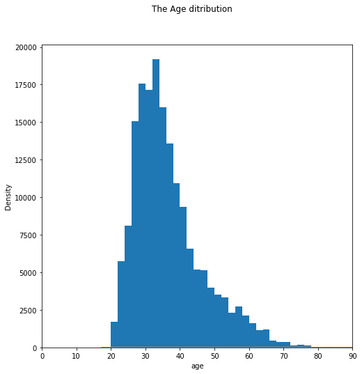

```python
# plotting the age
plt.figure(figsize=[8, 8])
plt.suptitle('The Age ditribution');
bins = np.arange(0, bike['age'].max()+2,2)
plt.hist(data=bike, x='age', bins=bins);
sb.distplot(bike.age)
plt.xlim((0,90));
```

```python
# remove the outliers from obove the 70 and less than 20
bike = bike.query('age <= 70')
bike = bike.query('age >= 20')
```

The data in the age have outliers so I remove the data before 20 and after 70.

```python
bike['start_hour'] = bike['start_hour'].astype(int)
bike['start_hour'].dtype
```

```
dtype('int64')
```

### 2.2. The starting trip hours and days investegation

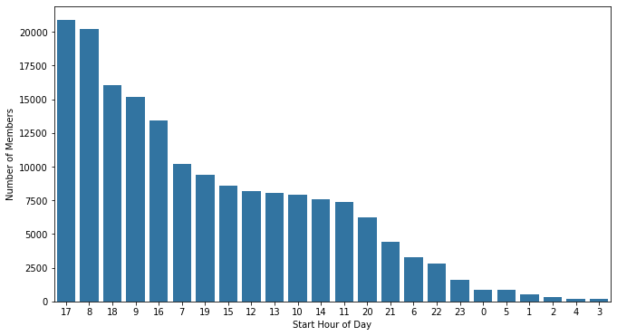

```python
# the blotting of the startting the trip of which hour a day
plt.suptitle('The star hour of day investigation');

plt.figure(figsize=[11, 6]);
freq = bike['start_hour'].value_counts()
gen_order = freq.index
base_color = sb.color_palette()[0]
sb.countplot(data=bike, x='start_hour', color=base_color, order=gen_order);
plt.xlabel('Start Hour of Day');
plt.ylabel('Number of Members');
```

Most of the data concentrated between hour 06 and hour 22 but their is no outliers, we can cut and start from hour 06.

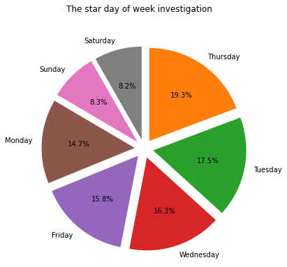

```python
# the blotting of the startting the trip of which day a week
plt.figure(figsize=[8, 6]);
plt.suptitle('The star day of week investigation');
day = ['Monday', 'Tuesday', 'Wednesday', 'Thursday', 'Friday', 'Saturday', 'Sunday']
daycat = pd.api.types.CategoricalDtype(ordered=True, categories=day)
bike['start_day'] = bike['start_day'].astype(daycat)
explode = (0.1, 0.1, 0.1, 0.1, 0.1, 0.1, 0.1);
sorted_vals = bike.start_day.value_counts()/bike.shape[0];
blue = ['#ff7f0e', '#2ca02c','#d62728', '#9467bd', '#8c564b', '#e377c2', '#7f7f7f']
plt.pie(sorted_vals, labels=sorted_vals.index, explode=explode, autopct='%1.1f%%', counterclock=False, startangle=90, colors= blue);
plt.axis('square');
```

- Thier is no outliers in this graph the data distributed on all the week's days.
- The least number of trips in saturday and sunday in weekend and the most frequent trips in thursday.

### 2.3. Duration outliers

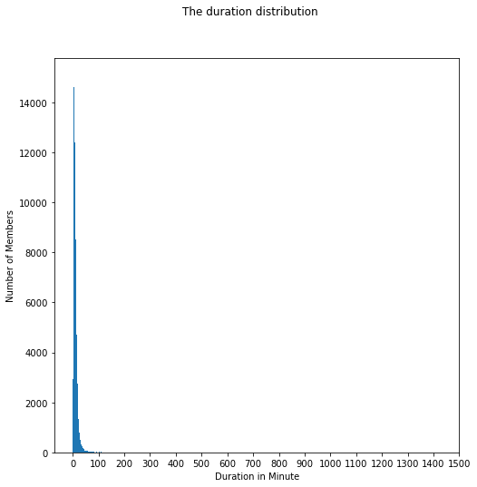

```python
plt.figure(figsize=[8, 8])
plt.suptitle('The duration distribution');
bins = np.arange(0, bike.duration_minute.max()+1, 1)
plt.hist(data=bike, x='duration_minute', bins=bins);
plt.xticks(np.arange(0, bike.duration_minute.max()+100, 100));
plt.xlabel('Duration in Minute');
plt.ylabel('Number of Members');
```

I need to cut the axis to see data clearly so will make the x-axis fro 0 to 70

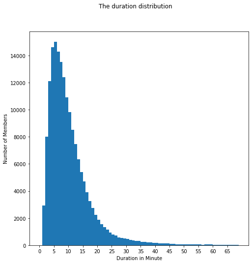

```python
# blotting the duration in minutes
plt.figure(figsize=[8, 8])
plt.suptitle('The duration distribution');

bins = np.arange(0, 70, 1)
plt.hist(data=bike, x='duration_minute', bins=bins);
plt.xticks(np.arange(0, 70, 5));
plt.xlabel('Duration in Minute');
plt.ylabel('Number of Members');
```

```python
# remove the outliers from duration
bike = bike.query('duration_minute <= 55')
bike = bike.query('duration_minute >= 1')
```

The concentation of the data duration between 1 to 35 minutes, the most frequent duration is 5 to 10 minutes.

### 2.4. User type, Gender, Bike_share_for_all_trip investigation

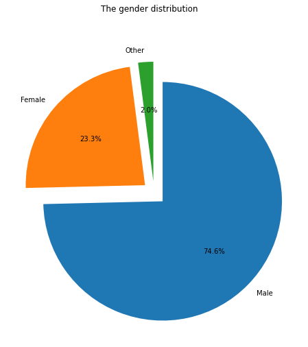

```python
# blotting of the gender
plt.figure(figsize=[8, 8]);
plt.suptitle('The gender distribution');

sorted_vals = bike.member_gender.value_counts()/bike.shape[0];
explode = (0.1, 0.1, 0.1);
plt.pie(sorted_vals, labels=sorted_vals.index, explode=explode, startangle=90, counterclock=False, autopct='%1.1f%%');
```

As the primary analysis the most frequent members in males, no outliers to delete it even if others is 2% of whole data.

```
 [Text(0.34029925736122496, -1.150737335554643, 'Subscriber'),
 [Text(0.19850790012738123, -0.6712634457402084, '90.8%'),
```

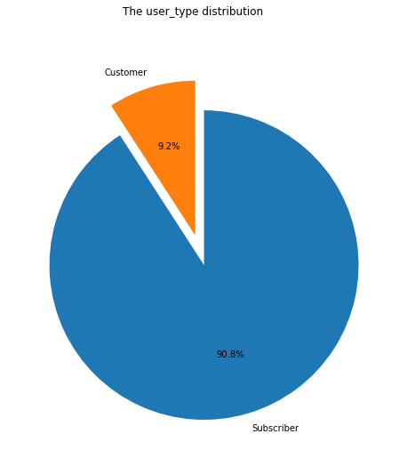

```python
# user_type plotting
plt.figure(figsize=[8, 8]);
plt.suptitle('The user_type distribution');

sorted_vals = bike.user_type.value_counts()/bike.shape[0];
explode = (0.1, 0.1);
plt.pie(sorted_vals, labels=sorted_vals.index, explode=explode, startangle=90, counterclock=False, autopct='%1.1f%%')
```

The most frequent yser type is Subsciber as the primary analysis.

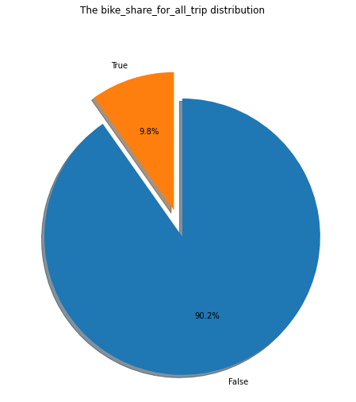

```python
# bike_share_for_all_trip plotting
plt.figure(figsize=[8, 8]);
plt.suptitle('The bike_share_for_all_trip distribution');

sorted_vals = bike.bike_share_for_all_trip.value_counts()/bike.shape[0];
explode = (0.1, 0.1);
plt.pie(sorted_vals, labels=sorted_vals.index, explode=explode, startangle=90, counterclock=False, autopct='%1.1f%%', shadow=True);
```

The most frequent bike_share_for_all_trip is False as the primary analysis.

### 2.5. Approximated distance investigation

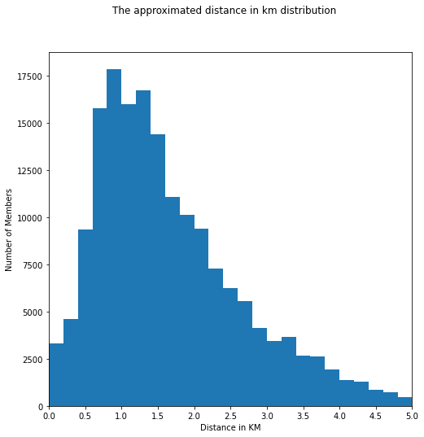

```python
# blotting the duration in minutes
plt.figure(figsize=[8, 8]);
plt.suptitle('The approximated distance in km distribution');

bins = np.arange(0, bike['app_distance_km'].max()+0.2, 0.2)
plt.hist(data=bike, x='app_distance_km', bins=bins);
plt.xticks(np.arange(0, bike['app_distance_km'].max()+0.5, 0.5));
plt.xlim((0,5));
plt.xlabel('Distance in KM');
plt.ylabel('Number of Members');
```

Make sure that, after every plot or related series of plots, that you include a Markdown cell with comments about what you observed, and what you plan on investigating next.

```python
# check to most distributed stating station id
bike.start_station_id.value_counts()
```

```
58.0     3629
67.0     3362
81.0     2899
21.0     2689
3.0      2560
         ...
301.0       8
51.0        7
224.0       4
300.0       3
344.0       2
Name: start_station_id, Length: 329, dtype: int64
```

```python
# check to most distributed end station id
bike.end_station_id.value_counts()
```

```
67.0     4585
58.0     3688
21.0     3425
15.0     3098
30.0     2826
         ...
51.0        9
300.0       6
224.0       5
301.0       4
344.0       4
Name: end_station_id, Length: 329, dtype: int64
```

### Discuss the distribution(s) of your variable(s) of interest. Were there any unusual points? Did you need to perform any transformations?

From the brevious analysis I found that:

- Most of the data concentrated between hour 06 and hour 22, with peaked around 8-9am and 17-18pm during a day.
- The least number of trips in saturday and sunday in weekend and the most frequent trips in thursday.
- The main members in the dataframe is males with 74.6% and females with 23.3%.
- The main members in the dataframe have a False in bike_share_for_all_trip by 90.1%.
- The main members in the dataframe was a Subscriber in user_type by 90.5%.
- Most of the members age concentrate in 30s & cncentated between 20 to 70.
- The trips distance frequent but concentated in 0.5 to 2.5 KM with high number of members from 0.5 to 1.2 KM
- The sation with Id 58 is the most frequent station members start their trips from it maybe this station have the member with age 30s
- the station with Id 67 is the most frequent station members end their trips from it.

### Of the features you investigated, were there any unusual distributions? Did you perform any operations on the data to tidy, adjust, or change the form of the data? If so, why did you do this?

At the duration the plotting need to be in smaller range to see clearly the data, as well as the app. distance.

```python
# save the clean data to a .csv file

bike.to_csv('bike_clean.csv', index=False)
```

## Bivariate Exploration

> In this section, investigate relationships between pairs of variables in your data. Make sure the variables that you cover here have been introduced in some fashion in the previous section (univariate exploration).

### 3.1. Duration Investigation

Duration of the trips diffrent on many factors:

- age due to interests of every individual and its activity.
- gender due to each gender have its routine and body ability.
- user_type and it's category due to it's activities during the day or lifestyle.

So in 3.1 analysis i will investigate about duration and it's reaction about age, gender, user_type, bike_shar, rush hours in day or rush days in week to find a patteren of helpfull investigation.

#### 3.1.1. Duration with User_type

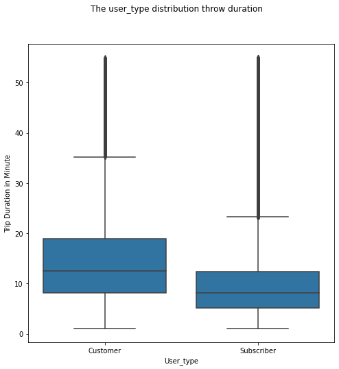

```python
plt.figure(figsize=[8, 8]);
plt.suptitle('The user_type distribution throw duration');
sb.boxplot(data=bike, x='user_type', y='duration_minute', color=base_color);
plt.xlabel('User_type');
plt.ylabel('Trip Duration in Minute');
```

The graph represent that in subscriber user_type the duration narrow that means that the subscriber type has a specific target in it's trip and achieve a goal comparing to customer who takes the bike for longer trips.

#### 3.1.2. Duration with Gender

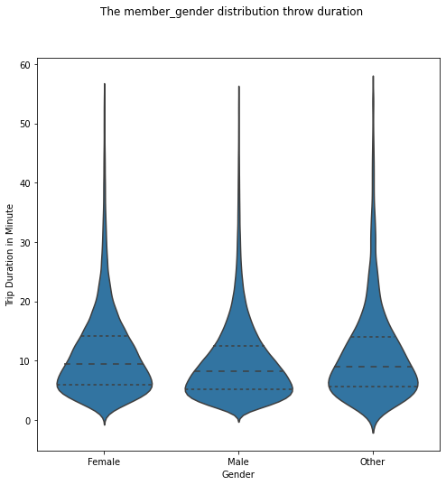

```python
plt.figure(figsize=[8, 8]);
plt.suptitle('The member_gender distribution throw duration');
sb.violinplot(data=bike, x='member_gender', y='duration_minute', color=base_color, inner='quartile');
plt.xlabel('Gender');
plt.ylabel('Trip Duration in Minute');
```

The trips for gender is nearly the same and have no addition information

#### 3.1.3. Duration with Bike_share_for_all_trip

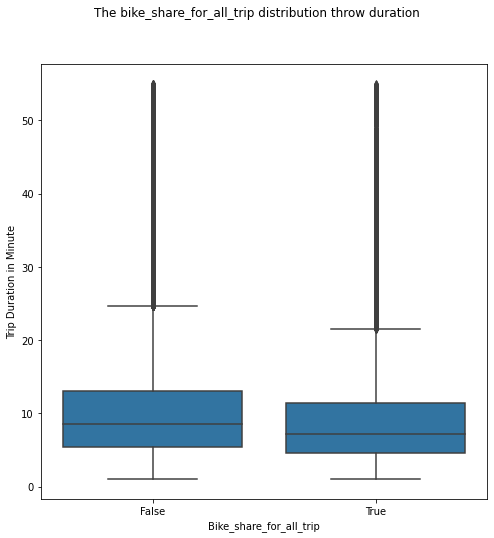

```python
plt.figure(figsize=[8, 8]);
plt.suptitle('The bike_share_for_all_trip distribution throw duration');
sb.boxplot(data=bike, x='bike_share_for_all_trip', y='duration_minute', color=base_color);
plt.xlabel('Bike_share_for_all_trip');
plt.ylabel('Trip Duration in Minute');
```

Their are no big diffrence in the bike_share_for_all_trip to add information in analysis.

#### 3.1.4. Average duration with Hour in the day

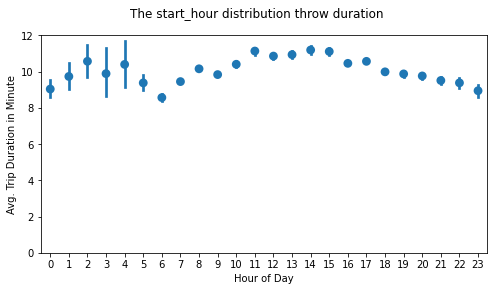

```python
plt.figure(figsize=[8, 4]);
plt.suptitle('The start_hour distribution throw duration');

sb.pointplot(data=bike, x='start_hour', y='duration_minute', color=base_color, linestyles="");
plt.ylim(0, 12)
plt.xlabel('Hour of Day');
plt.ylabel('Avg. Trip Duration in Minute');
```

#### 3.1.5. Average duration with day in the week

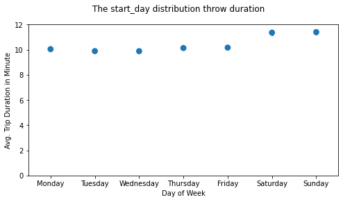

```python
plt.figure(figsize=[8, 4]);
plt.suptitle('The start_day distribution throw duration');

sb.pointplot(data=bike, x='start_day', y='duration_minute', color=base_color, linestyles="");
plt.ylim(0, 12)
plt.xlabel('Day of Week');
plt.ylabel('Avg. Trip Duration in Minute');
```

The riders in the working days at the week have nearly the same average duration for trip compered to weekend days that take longer duration.

### 3.2. Age investigation

The age is a main factor in investigation due to the diffrent in routins for each generation. in 3.2 i will investigate about age and it's reaction aboutgender, user_type to find a patteren of helpfull investigation.

#### 3.2.1. Age with User_type

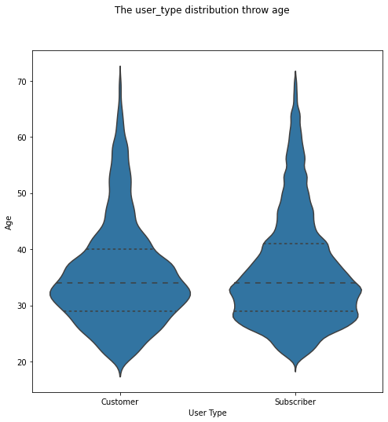

```python
plt.figure(figsize=[8, 8]);
plt.suptitle('The user_type distribution throw age');

sb.violinplot(data=bike, x='user_type', y='age', color=base_color, inner='quartile');
plt.xlabel('User Type');
plt.ylabel('Age');
```

The age of the customer type narrower than the subscriber type.

#### 3.2.2. Age duration with Gender

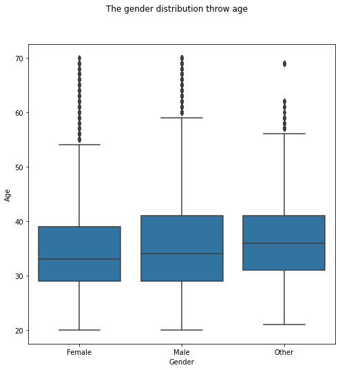

```python
plt.figure(figsize=[8, 8]);
plt.suptitle('The gender distribution throw age');
sb.boxplot(data=bike, x='member_gender', y='age', color=base_color);
plt.xlabel('Gender');
plt.ylabel('Age');
```

The age for females narrower than males.

### 3.3. User Type investigation

The user type or the category of the rider is most important in affecting the data due to it's routine throw the hole day and week.

So in 3.3 analysis i will investigate about user_type and it's reaction about hours in day and days in week to find a patteren of helpfull investigation.

#### 3.3.1. User type with hour of the day

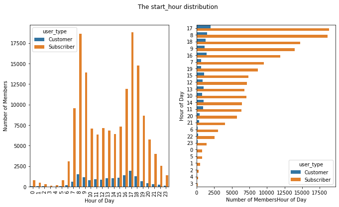

```python
plt.figure(figsize=[11, 6]);
plt.suptitle('The start_hour distribution');

plt.subplot(1, 2, 1);
sb.countplot(data=bike, x='start_hour', hue='user_type');
plt.xticks(rotation=90);
plt.xlabel('Hour of Day');
plt.ylabel('Number of Members');
plt.subplot(1, 2, 2);
freq = bike['start_hour'].value_counts()
gen_order = freq.index
sb.countplot(data=bike, y='start_hour', hue='user_type', order=gen_order);
plt.xlabel('Number of MembersHour of Day');
plt.ylabel('Hour of Day');
```

Riders are starting trips and get to peak at mornning, then decrease trips at afternoon then increase again at night to hit peak.

#### 3.3.2. User type with day of the week

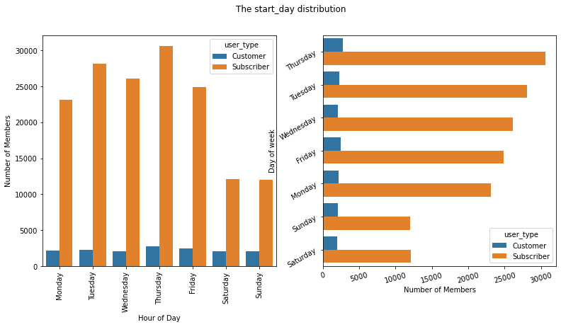

```python
plt.figure(figsize=[13, 6]);
plt.suptitle('The start_day distribution');
plt.subplot(1, 2, 1);
sb.countplot(data=bike, x='start_day', hue='user_type');
plt.xticks(rotation=90);
plt.xlabel('Hour of Day');
plt.ylabel('Number of Members');
plt.subplot(1, 2, 2);
freq = bike['start_day'].value_counts()
gen_order = freq.index
sb.countplot(data=bike, y='start_day', hue='user_type', order=gen_order);
plt.xticks(rotation=15);
plt.yticks(rotation=30);
plt.xlabel('Number of Members');
plt.ylabel('Day of week');
```

The number of subscriber much bigger from monday to friday than the weekend, unlikely the customer type which nearly the same.

### Talk about some of the relationships you observed in this part of the investigation. How did the feature(s) of interest vary with other features in the dataset?

- According to the investigation draws about the subscribers that a use the bike sharing system for work commnute thus most trips were on work days (Mon-Fri) and especially during rush hours unlike the customer that nearly the same riding trips throw the hole week but take long trips in weekend.
- the females with older age is less than males.

### Did you observe any interesting relationships between the other features (not the main feature(s) of interest)?

- subscriber type is slightly older than custumer type but faster riders.

## Multivariate Exploration

> Create plots of three or more variables to investigate your data even further. Make sure that your investigations are justified, and follow from your work in the previous sections.

### 4.1. Duration for each type in gender by the age of rider

In 4.1 I will investegate on duration for each type in gender by the age of rider to see a big picture about analysis relations.

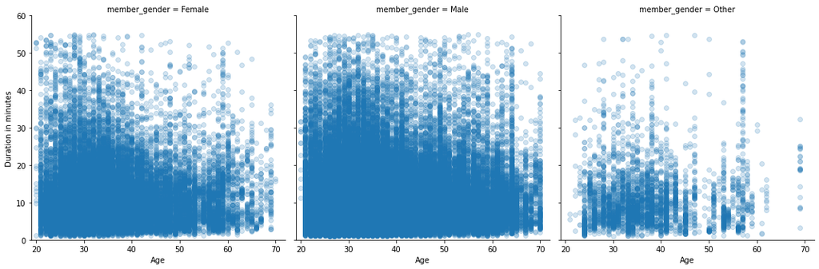

```python
plt.suptitle('The Age with duration distribution in each gender ');
gender = sb.FacetGrid(data = bike, col = 'member_gender', col_wrap = 3, size = 5, xlim = [19, 72], ylim = [0, 60])
gender.map(plt.scatter, 'age', 'duration_minute', alpha= 0.2)
gender.set_xlabels('Age')
gender.set_ylabels('Duration in minutes')
plt.show()
```

This analysis represent that

- The number of the riders in concentrated in the middle-left and decresses with increasing the age.
- The duration of the trips in female riders decreases from age 35.
- The number of the female riders decreases as increasing age more than males riders
- The other is the least riders and concentated between 22 to 45 with a the shortest duration in their trips.

### 4.2. The Hourly Usage during Weekdays for Customers and Subscribers

In the brevious section, i found that each user type has it's own effect on the rush hours throw the day and days of week due to changing in it's activities throw the day and hole week.

In 4.2, i will investigate about The Hourly Usage during Weekdays for Customers and Subscribers to see a big picture about analysis relations.

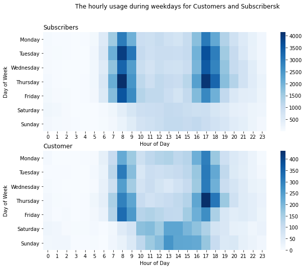

```python
plt.figure(figsize=[10, 8]);
plt.suptitle('The hourly usage during weekdays for Customers and Subscribersk ');
# the Hourly Usage during Weekdays for Subscribers
plt.subplot(2, 1, 1)
subscribers = bike.query('user_type == "Subscriber"')
s = subscribers.groupby(['start_day', 'start_hour']).size()
s = s.reset_index(name='count')
s = s.pivot(index='start_day', columns='start_hour', values='count')
sb.heatmap(s, cmap='Blues');
plt.title('Subscribers', loc='left');
plt.xlabel('Hour of Day');
plt.ylabel('Day of Week');
# the Hourly Usage during Weekdays for Customers
plt.subplot(2, 1, 2)
customers = bike.query('user_type == "Customer"')
c = customers.groupby(['start_day', 'start_hour']).size()
c = c.reset_index(name='count')
c = c.pivot(index='start_day', columns='start_hour', values='count')
sb.heatmap(c, cmap='Blues');
plt.title('Customer', loc='left');
plt.xlabel('Hour of Day');
plt.ylabel('Day of Week');
```

The analysis represent that

- For subscribers: the number of riders concentated in (Mon-to-Fri)to hit the peak in Tuesday and Thursday, and concentated in early hours a day (06:30 to 09:00) and the afternoon (15:30 to 18:30), leaving a conlusion that a subscribers ride for hiting a target or goal or work comitment.
- For customers: Have the same features of the Subscribers in number of the riders oncentated in (Mon-to-Fri)in the same rush houres like subscribers, but for weekends (sat, sun) theirs also a densty in the graph between 9:30 to 17:00.

### 4.3. The Avg. duration for customers and subscribers throw the week aganist distance

In the brevious section, i found that riders with each user type change it's activities throw the hole week.

In 4.3, i will investigate about The Avg. duration for customers and subscribers throw the week aganist distance to see a big picture about analysis relations.

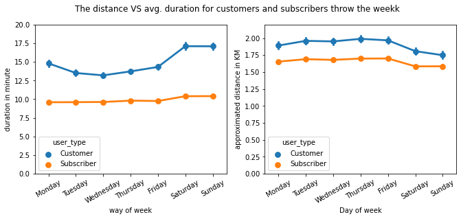

```python
plt.figure(figsize=[11, 4]);
plt.suptitle('The distance VS avg. duration for customers and subscribers throw the weekk ');
plt.subplot(1, 2, 1);
sb.pointplot(data=bike, x='start_day', y='duration_minute', hue='user_type');
plt.ylim(0, 20)
plt.xticks(rotation=30);
plt.xlabel('way of week');
plt.ylabel('duration in minute');
plt.subplot(1, 2, 2);
sb.pointplot(data=bike, x='start_day', y='app_distance_km', hue='user_type');
plt.ylim(0, 2.2)
plt.xticks(rotation=30);
plt.xlabel('Day of week');
plt.ylabel('approximated distance in KM');
```

The subscriber take a short time in the trips but according to the distance graph means that the subscriber take shorter time and much quecker than customers. The duration for trips increases in saturday and sunday for the two types.

### Talk about some of the relationships you observed in this part of the investigation. Were there features that strengthened each other in terms of looking at your feature(s) of interest?

leaping for other gender at an older is a surprise. the observation with gender was inbalnced in number of feamles and males rider, the observation is not quite helpful.

> At the end of your report, make sure that you export the notebook as an html file from the `File > Download as... > HTML` menu. Make sure you keep track of where the exported file goes, so you can put it in the same folder as this notebook for project submission. Also, make sure you remove all of the quote-formatted guide notes like this one before you finish your report!